# Point patterns analysis of IBA1 and CD68 cells for DKK1 ON and DKK1 Off animals after ischemia

Data analysis notebook

Author

Affiliation

Daniel Manrique-Castano, PhD

Univerisity Laval

Published

Sunday, August 11, 2024

Keywords

DKK1, MCAO, Brain injury, Bayesian modeling

This notebook develops point patterns analysis (PPA) for a set of points (xy coordinates) derived from stained cells. The cells were unbiased detected using QuPath (*1*) and stored as .tsv files (`2024_DKK1_CellDetections`) that were processed to create point patterns (`2024_DKK1_Hyperfraes`).

# 1 1. Install and load required packages

First, we install and load the required libraries. To perform a first installation, please uncomment (erase #) the ‘install.packages’ line in the following chunk. For subsequent code execution, comment again the installation line.

```r
# To install packcages uncomment the following line

#install.packages(c("ggplot2","dpylr", "ggridges", "raincloudplots", "cowplot", "data.table", "ggrepel", "sjPlot", "bayesplot", "reshape2", "purrr", "tidyr", "brms", "emmeans", "modelr", "plyr", "pacthwork", "spatstat", "ggdist", "ggpubr", "bayesplot", "RandomFieldsUtils", "RandomFields"))

#library(devtools)
#install_github ("cran/RandomFields")

library(brms)
library(tidybayes)
library(ggplot2)
library(dplyr)
library(landscapemetrics)
library(modelr)
library(patchwork)
library(raster)
library(spatstat)
library(tidyr)
```

We load also a plot theme

```r
Plot_theme <- theme_classic() +
  theme(
      plot.title = element_text(size=18, hjust = 0.5, face="bold"),
      plot.subtitle = element_text(size = 10, color = "black"),
      plot.caption = element_text(size = 12, color = "black"),
      axis.line = element_line(colour = "black", size = 1.5, linetype = "solid"),
      axis.ticks.length=unit(7,"pt"),

      axis.title.x = element_text(colour = "black", size = 16),
      axis.text.x = element_text(colour = "black", size = 16, angle = 0, hjust = 0.5),
      axis.ticks.x = element_line(colour = "black", size = 1),

      axis.title.y = element_text(colour = "black", size = 16),
      axis.text.y = element_text(colour = "black", size = 16),
      axis.ticks.y = element_line(colour = "black", size = 1),

      legend.position="right",
      legend.direction="vertical",
      legend.title = element_text(colour="black", face="bold", size=12),
      legend.text = element_text(colour="black", size=10),

      plot.margin = margin(t = 10,  # Top margin
                             r = 2,  # Right margin
                             b = 10,  # Bottom margin
                             l = 10) # Left margin
      )
```

# 2 Analysis of Iba1

## 2.1 Load the point patterns

We load the `Iba1_PointPatterns` file containing the point patterns for the detect cells. Then, we calculate density kernels and plot the for verification.

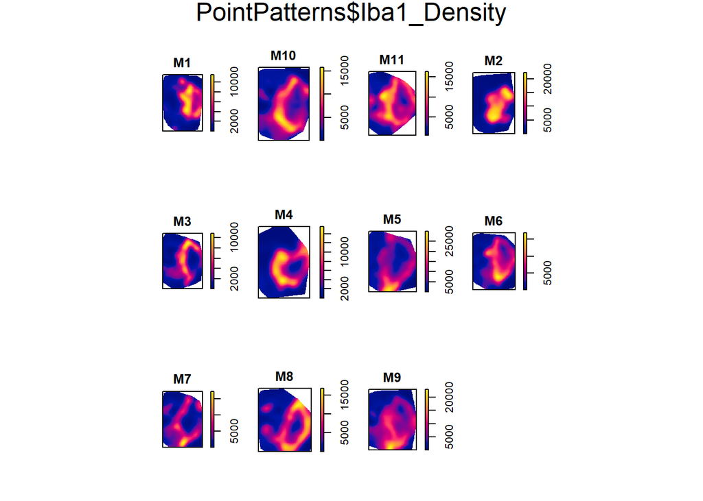

```r
# Load hyperframes with point patterns
PointPatterns <- readRDS("PointPatterns/Iba1_PPP.rds")

PointPatterns$Condition <- factor(PointPatterns$Condition, levels = c("Off", "ON"))
PointPatterns$Iba1 <- with(PointPatterns, rotate.ppp(Iba1, pi))

# Calculate density kernels
PointPatterns$Iba1_Density <- with (PointPatterns, density(Iba1, sigma = 0.1))
plot(PointPatterns$Iba1_Density)
```

We use this code to seve individual density kernels:

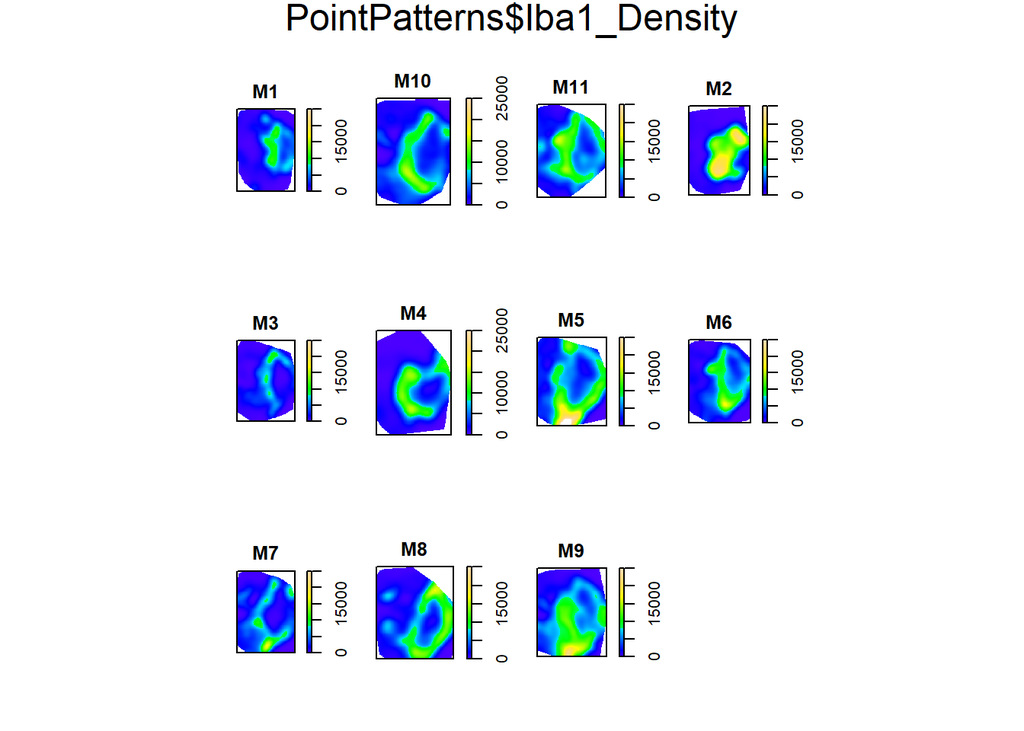

```r
Colmap <- colourmap(topo.colors(256), range = c(0, 25000))

plot(PointPatterns$Iba1_Density, col = Colmap)
```

```r
par(mar=c(1,1,1,1), oma=c(1,1,1,1))
png("Plots/Density_Iba1_M11.png", width = 300, height = 600)
par(mar=c(1,1,1,1), oma=c(1,1,1,1))
plot(PointPatterns$Iba1_Density$M11, col = Colmap, main = "M11_ON")
dev.off()
```

## 2.2 Calculate tesselations we create Tessellations and quadrant counts

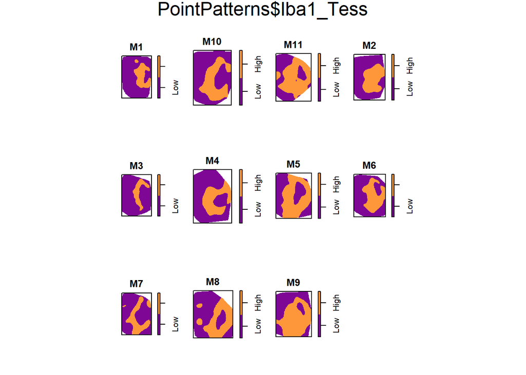

```r
# Calculate tessellations
Cells_Quantiles <- c(0, 5000, 40000)
PointPatterns$Iba1_Tess <- with (PointPatterns, cut(Iba1_Density, breaks = Cells_Quantiles, labels = c ("Low", "High")))

plot(PointPatterns$Iba1_Tess)
```

```r
PointPatterns$Iba1_Counts <- with(PointPatterns, quadratcount(Iba1, tess = Iba1_Tess))
```

Next, we organize a table with the quadrant counts

```r
Counts <- as.data.frame(PointPatterns$Iba1_Counts)

Counts_long <- pivot_longer(
  Counts,
  cols = everything(),
  names_to = c("Tile", ".value"),
  names_pattern = "(M\\d+)\\.(.*)"
)

# Add 'Condition' column with repeating patterns
Counts_long <- Counts_long  %>%
  mutate(Condition = rep(c("Off", "ON", "Off", "ON"), times = c(6, 5, 6, 5)))

# View the updated dataframe
print(Counts_long)
```

```
# A tibble: 22 x 4
   Tile  tile   Freq Condition
   <chr> <fct> <int> <chr>
 1 M1    Low    3560 Off
 2 M10   Low    6829 Off
 3 M11   Low    3836 Off
 4 M2    Low    1431 Off
 5 M3    Low    4606 Off
 6 M4    Low    2007 Off
 7 M5    Low    4263 ON
 8 M6    Low    4294 ON
 9 M7    Low    5990 ON
10 M8    Low    4142 ON
# i 12 more rows
```

```r
Counts_long_sub <- Counts_long[Counts_long$tile == "High",]
```

## 2.3 Statistical modeling

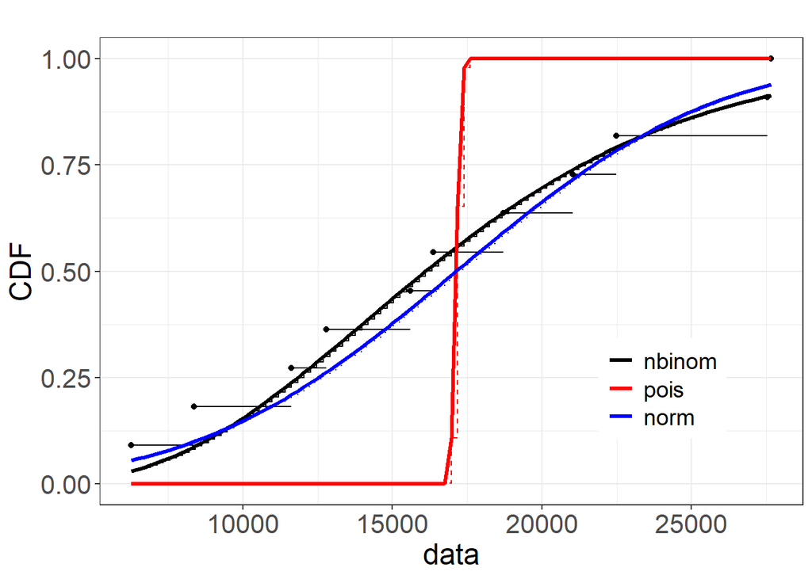

```r
library(fitdistrplus)

Iba1.nbinom <- fitdist(Counts_long_sub$Freq, "nbinom")
Iba1.pois <- fitdist(Counts_long_sub$Freq, "pois")
Iba1.norm <- fitdist(Counts_long_sub$Freq, "norm")


bac.cdf <- cdfcomp(list(Iba1.nbinom, Iba1.pois,Iba1.norm),
                main="",legendtext=c("nbinom","pois", "norm"),
                fitcol = c("black", "red", "blue"),
                plotstyle ="ggplot")+
geom_line(linewidth=1.2)+
theme(axis.title=element_text(size=18),
axis.text = element_text(size=16),
legend.position = c(0.8,0.25),
legend.text=element_text(size=14))

bac.cdf
```

## 2.4 Fit the model for cell counts

```r
Iba1_Mdl1 <- bf(Freq ~ Condition)

get_prior(Iba1_Mdl1, data = Counts_long_sub, family = student)
```

```
                       prior     class        coef group resp dpar nlpar lb ub
                      (flat)         b
                      (flat)         b ConditionON
 student_t(3, 16374, 7064.6) Intercept
               gamma(2, 0.1)        nu                                    1
     student_t(3, 0, 7064.6)     sigma                                    0
       source
      default
 (vectorized)
      default
      default
      default
```

```r
# Fit model 1
Iba1_Fit1 <-
  brm(
    data    = Counts_long_sub,
    family  = student,
    formula = Iba1_Mdl1,
    chains  = 4,
    cores   = 4,
    warmup  = 2500,
    iter    = 5000,
    seed    = 8807,
    control = list(adapt_delta = 0.99, max_treedepth = 15),
    file    = "Models/Iba1_Fit1.rds",
    file_refit = "never")

# Add criteria for comparison
Iba1_Fit1 <-
  add_criterion(Iba1_Fit1, c("loo", "waic", "bayes_R2"))
```

## 2.5 Plot the results

```r
Iba1_fig <-  Counts_long_sub %>%
  data_grid(Condition) %>%
  add_epred_draws(Iba1_Fit1) %>%
  ggplot(aes(x = .epred, y = Condition, fill = after_stat(abs(x) < 20295))) +
  geom_vline(xintercept = c(8111, 20295), linetype = "dashed") +
  stat_pointinterval(.width = c(.66, .95)) +
  stat_halfeye() +
  scale_fill_manual(
    name="ROPE",
    values = c("gray80", "skyblue"),
    labels = c("False", "True")) +
  scale_x_continuous(name = "Number of Iba1+ cells") +
  theme_classic() +
  Plot_theme +
  theme (legend.position = c(0.8, 0.3))

ggsave(plot = Iba1_fig ,
       "Plots/Iba1_Counts.png",
       width = 11,
       height = 9,
       units = "cm")
```

## 2.6 Analysis of the relative distribution (x-axis)

We analyze the distribution of Iba1+ cells conditional on the x-axis.

```r
Iba1_ON <- subset(PointPatterns, Condition=="ON", select = 1:5)
Iba1_Off <- subset(PointPatterns, Condition=="Off", select = 1:5)

Iba1_ON_Rohat <- with(Iba1_ON, spatstat.explore::rhohat.ppp(Iba1, "x", do.CI = FALSE))
Iba1_ON_Rohat <- pool(Iba1_ON_Rohat)

Iba1_Off_Rohat <- with(Iba1_Off, spatstat.explore::rhohat.ppp(Iba1, "x", do.CI = FALSE))
Iba1_Off_Rohat <- pool(Iba1_Off_Rohat)
```

### 2.6.1 Plot the rhohat

```r
## For DKK1 ON

png("Plots/Iba1_DKK1_ON.png", width = 600, height = 400)
par(mar=c(5,8,0.5,0.5)+2)
plot(Iba1_ON_Rohat,
     shade = c("lorho", "hirho"),
     las=1,
     legendargs=list(xpd=TRUE),
     main = "ON",
     ylim =c(0, 10000),
     xlab = "",
     ylab = "",
     cex.main = 2.5,
     cex.lab = 2.5,
     cex.axis = 2.5,
     lwd = 3,
     legend=FALSE,
     xaxt = "n",
     yaxt = "n")
     #col = "black")

# Add 'lorho' and 'hirho' lines with specific colors
#lines(Iba1_ON_Rohat$x, Iba1_ON_Rohat$poolave, col="black", lwd=3, lty = 3)
#lines(Iba1_ON_Rohat$x, Iba1_ON_Rohat$loave, col="black", lwd=3, lty = 1)
#lines(Iba1_ON_Rohat$x, Iba1_ON_Rohat$hiave, col="black", lwd=3, lty = 1)

axis(1, at = seq(-2.3, 0, 0.5), labels = c("0", "0.5", "1", "1.5",  "2"), cex.axis=2.5, padj = 0.5, lwd.ticks = 5)

axis(2, at = seq(0, 10000, 2000), labels = c("0","2000", "4000", "6000", "8000", "10000"), cex.axis=2.5, padj = 0.5, lwd.ticks = 5, las = 2)

title(xlab = "X coordinates", mgp = c(4.5, 1, 0), cex.lab = 2.5)
title(ylab = "p(IBA1)", mgp = c(7, 1, 0), cex.lab = 2.5)

dev.off()
## For DKK1 ON
png("Plots/Iba1_DKK1_Off.png", width = 600, height = 400)
par(mar=c(5,8,0.5,0.5)+2)
plot(Iba1_Off_Rohat,
     shade = c("lorho", "hirho"),
     las=1,
     legendargs=list(xpd=TRUE),
     main = "Off",
     ylim =c(0, 10000),
     xlab = "",
     ylab = "",
     cex.main = 2.5,
     cex.lab = 2.5,
     cex.axis = 2.5,
     lwd = 3,
     legend=FALSE,
     xaxt = "n",
     yaxt = "n")
     #col = "black")

# Add 'lorho' and 'hirho' lines with specific colors
#lines(Iba1_Off_Rohat$x, Iba1_Off_Rohat$poolave, col="black", lwd=3, lty = 3)
#lines(Iba1_Off_Rohat$x, Iba1_Off_Rohat$loave, col="black", lwd=3, lty = 1)
#lines(Iba1_Off_Rohat$x, Iba1_Off_Rohat$hiave, col="black", lwd=3, lty = 1)

axis(1, at = seq(-2, 0, 0.5), labels = c("0", "0.5", "1", "1.5",  "2"), cex.axis=2.5, padj = 0.5, lwd.ticks = 5)

axis(2, at = seq(0, 10000, 2000), labels = c("0","2000", "4000", "6000", "8000", "10000"), cex.axis=2.5, padj = 0.5, lwd.ticks = 5, las = 2)

title(xlab = "X coordinates", mgp = c(4.5, 1, 0), cex.lab = 2.5)
title(ylab = "p(IBA1)", mgp = c(7, 1, 0), cex.lab = 2.5)
dev.off()
```

## 2.7 Plot the rohat values

```r
print(paste("The mean spatial intensity for IBA1 in DKK1 ON is:", mean(Iba1_ON_Rohat$poolave)))
```

```
[1] "The mean spatial intensity for IBA1 in DKK1 ON is: 5048.36426403765"
```

```r
print(paste("The higher 95% CI for IBA1 in DKK1 ON is:", mean(Iba1_ON_Rohat$hiave)))
```

```
[1] "The higher 95% CI for IBA1 in DKK1 ON is: 5985.53122075856"
```

```r
print(paste("The lower 95% CI for IBA1 in DKK1 ON is:", mean(Iba1_ON_Rohat$loave)))
```

```
[1] "The lower 95% CI for IBA1 in DKK1 ON is: 4111.19730731673"
```

```r
print(paste("The mean spatial intensity for IBA1 in DKK1 Off is:", mean(Iba1_Off_Rohat$poolave)))
```

```
[1] "The mean spatial intensity for IBA1 in DKK1 Off is: 4275.55168669009"
```

```r
print(paste("The higher 95% CI for IBA1 in DKK1 Off is:", mean(Iba1_Off_Rohat$hiave)))
```

```
[1] "The higher 95% CI for IBA1 in DKK1 Off is: 5584.87620350366"
```

```r
print(paste("The lower 95% CI for IBA1 in DKK1 Off is:", mean(Iba1_Off_Rohat$loave)))
```

```
[1] "The lower 95% CI for IBA1 in DKK1 Off is: 2966.22716987653"
```

## 2.8 Fit the mppm model

```r
Iba1_mppm1 <- mppm(Iba1 ~ 0 + Condition, data = PointPatterns)
Iba1_mppm1_Coeff <- round(exp(coef(Iba1_mppm1)), digits = 2)
Iba1_mppm1_CI <- round(exp(confint(Iba1_mppm1)), digits = 2)

Iba1_mppm2 <- mppm(Iba1 ~ 0 + Condition * x, data = PointPatterns)
Iba1_mppm2_Coeff <- round(exp(coef(Iba1_mppm2)), digits = 2)
Iba1_mppm2_CI <- round(exp(confint(Iba1_mppm2)), digits = 2)
```

# 3 Analysis of CD68

## 3.1 Load the point patterns

We perform the same procedure for CD68-stained brain sections:

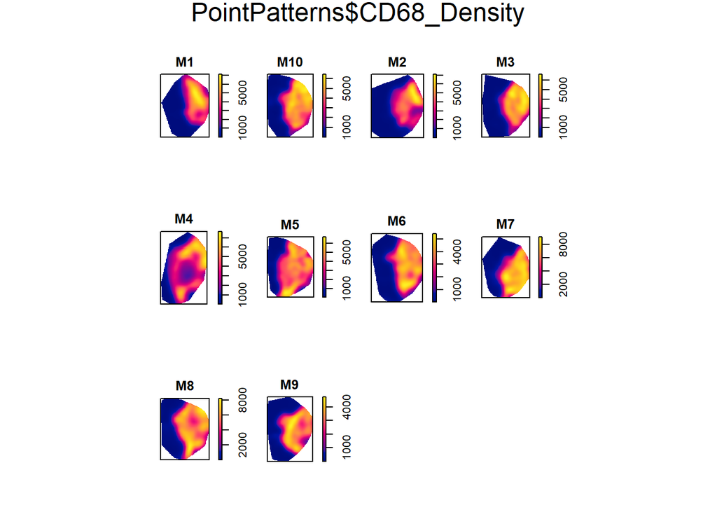

```r
# Load hyperframes with point patterns
PointPatterns <- readRDS("PointPatterns/CD68_PPP.rds")

PointPatterns$Condition <- factor(PointPatterns$Condition, levels = c("Off", "On"))
PointPatterns$CD68 <- with(PointPatterns, rotate.ppp(CD68, pi))

# Calculate density kernels
PointPatterns$CD68_Density <- with (PointPatterns, density(CD68, sigma = 0.1))
plot(PointPatterns$CD68_Density)
```

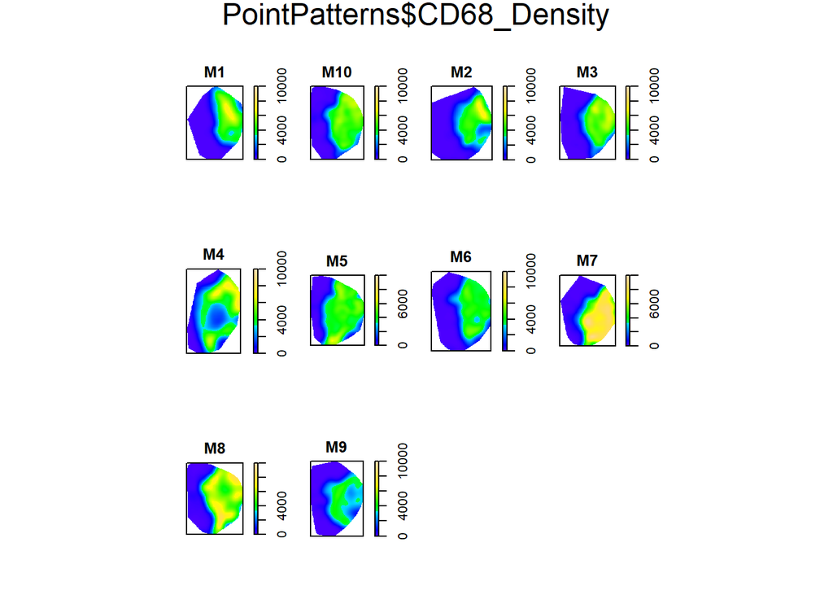

```r
Colmap <- colourmap(topo.colors(256), range = c(0, 10000))

plot(PointPatterns$CD68_Density, col = Colmap)
```

```r
par(mar=c(1,1,1,1), oma=c(1,1,1,1))
png("Plots/Density_CD68_M10.png", width = 300, height = 600)
par(mar=c(1,1,1,1), oma=c(1,1,1,1))
plot(PointPatterns$CD68_Density$M10, col = Colmap, main = "M10_On")
dev.off()
```

## 3.2 Calculate tesselations we create Tessellations and quadrant counts

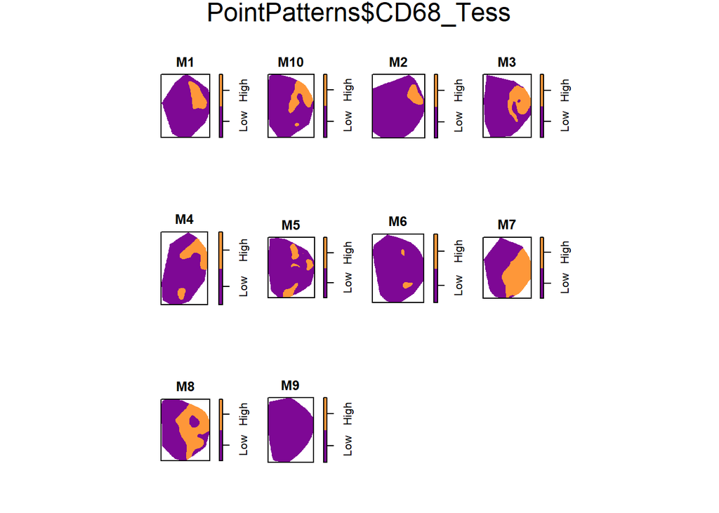

```r
# Calculate tessellations
Cells_Quantiles <- c(0, 5000, 40000)
PointPatterns$CD68_Tess <- with (PointPatterns, cut(CD68_Density, breaks = Cells_Quantiles, labels = c ("Low", "High")))

plot(PointPatterns$CD68_Tess)
```

```r
PointPatterns$CD68_Counts <- with(PointPatterns, quadratcount(CD68, tess = CD68_Tess))
```

## 3.3 Analysis of the relative distribution (x-axis)

We analyze the distribution of CD68+ cells conditional on the x-axis.

```r
CD68_ON <- subset(PointPatterns, Condition=="On", select = 1:5)
CD68_Off <- subset(PointPatterns, Condition=="Off", select = 1:5)

CD68_ON_Rohat <- with(CD68_ON, spatstat.explore::rhohat.ppp(CD68, "x", do.CI = FALSE))
CD68_ON_Rohat <- pool(CD68_ON_Rohat)

CD68_Off_Rohat <- with(CD68_Off, spatstat.explore::rhohat.ppp(CD68, "x", do.CI = FALSE))
CD68_Off_Rohat <- pool(CD68_Off_Rohat)
```

### 3.3.1 Plot the rhohat

```r
## For DKK1 ON

png("Plots/CD68_DKK1_ON.png", width = 600, height = 400)
par(mar=c(5,8,0.5,0.5)+2)
plot(CD68_ON_Rohat,
     shade = c("lorho", "hirho"),
     las=1,
     legendargs=list(xpd=TRUE),
     main = "ON",
     ylim =c(0, 8000),
     xlab = "",
     ylab = "",
     cex.main = 2.5,
     cex.lab = 2.5,
     cex.axis = 2.5,
     lwd = 3,
     legend=FALSE,
     xaxt = "n",
     yaxt = "n")
     #col = "black")

# Add 'lorho' and 'hirho' lines with specific colors
#lines(CD68_ON_Rohat$x, CD68_ON_Rohat$poolave, col="black", lwd=3, lty = 3)
#lines(CD68_ON_Rohat$x, CD68_ON_Rohat$loave, col="black", lwd=3, lty = 1)
#lines(CD68_ON_Rohat$x, CD68_ON_Rohat$hiave, col="black", lwd=3, lty = 1)

axis(1, at = seq(-2.3, 0, 0.5), labels = c("0", "0.5", "1", "1.5",  "2"), cex.axis=2.5, padj = 0.5, lwd.ticks = 5)

axis(2, at = seq(0, 8000, 2000), labels = c("0","2000", "4000", "6000", "8000"), cex.axis=2.5, padj = 0.5, lwd.ticks = 5, las = 2)

title(xlab = "X coordinates", mgp = c(4.5, 1, 0), cex.lab = 2.5)
title(ylab = "p(CD68)", mgp = c(7, 1, 0), cex.lab = 2.5)

dev.off()
## For DKK1 Off
png("Plots/CD68_DKK1_Off.png", width = 600, height = 400)
par(mar=c(5,8,0.5,0.5)+2)
plot(CD68_Off_Rohat,
     shade = c("lorho", "hirho"),
     las=1,
     legendargs=list(xpd=TRUE),
     main = "Off",
     ylim =c(0, 8000),
     xlab = "",
     ylab = "",
     cex.main = 2.5,
     cex.lab = 2.5,
     cex.axis = 2.5,
     lwd = 3,
     legend=FALSE,
     xaxt = "n",
     yaxt = "n")
     #col = "black")

# Add 'lorho' and 'hirho' lines with specific colors
#lines(CD68_Off_Rohat$x, CD68_Off_Rohat$poolave, col="black", lwd=3, lty = 3)
#lines(CD68_Off_Rohat$x, CD68_Off_Rohat$loave, col="black", lwd=3, lty = 1)
#lines(CD68_Off_Rohat$x, CD68_Off_Rohat$hiave, col="black", lwd=3, lty = 1)

axis(1, at = seq(-2, 0, 0.5), labels = c("0", "0.5", "1", "1.5",  "2"), cex.axis=2.5, padj = 0.5, lwd.ticks = 5)

axis(2, at = seq(0, 8000, 2000), labels = c("0","2000", "4000", "6000", "8000"), cex.axis=2.5, padj = 0.5, lwd.ticks = 5, las = 2)

title(xlab = "X coordinates", mgp = c(4.5, 1, 0), cex.lab = 2.5)
title(ylab = "p(CD68)", mgp = c(7, 1, 0), cex.lab = 2.5)
dev.off()
```

## 3.4 Plot the rohat values

```r
print(paste("The mean spatial intensity for IBA1 in DKK1 ON is:", mean(CD68_ON_Rohat$poolave)))
```

```
[1] "The mean spatial intensity for IBA1 in DKK1 ON is: 2810.013390726"
```

```r
print(paste("The higher 95% CI for IBA1 in DKK1 ON is:", mean(CD68_ON_Rohat$hiave)))
```

```
[1] "The higher 95% CI for IBA1 in DKK1 ON is: 3734.77481529195"
```

```r
print(paste("The lower 95% CI for IBA1 in DKK1 ON is:", mean(CD68_ON_Rohat$loave)))
```

```
[1] "The lower 95% CI for IBA1 in DKK1 ON is: 1885.25196616005"
```

```r
print(paste("The mean spatial intensity for IBA1 in DKK1 Off is:", mean(CD68_Off_Rohat$poolave)))
```

```
[1] "The mean spatial intensity for IBA1 in DKK1 Off is: 2341.46485358632"
```

```r
print(paste("The higher 95% CI for IBA1 in DKK1 Off is:", mean(CD68_Off_Rohat$hiave)))
```

```
[1] "The higher 95% CI for IBA1 in DKK1 Off is: 2776.22665473185"
```

```r
print(paste("The lower 95% CI for IBA1 in DKK1 Off is:", mean(CD68_Off_Rohat$loave)))
```

```
[1] "The lower 95% CI for IBA1 in DKK1 Off is: 1906.70305244079"
```

## 3.5 Fit the mppm model

```r
CD68_mppm1 <- mppm(CD68 ~ 0 + Condition, data = PointPatterns)
CD68_mppm1_Coeff <- round(exp(coef(CD68_mppm1)), digits = 2)
CD68_mppm1_CI <- round(exp(confint(CD68_mppm1)), digits = 2)

CD68_mppm2 <- mppm(CD68 ~ 0 + Condition * x, data = PointPatterns)
CD68_mppm2_Coeff <- round(exp(coef(CD68_mppm2)), digits = 2)
CD68_mppm2_CI <- round(exp(confint(CD68_mppm2)), digits = 2)
```

## References

1.

P. Bankhead, M. B. Loughrey, J. A. Fernández, Y. Dombrowski, D. G. McArt, P. D. Dunne, S. McQuaid, R. T. Gray, L. J. Murray, H. G. Coleman, J. A. James, M. Salto-Tellez, P. W. Hamilton, QuPath: Open source software for digital pathology image analysis. *Scientific Reports*. **7** (2017), doi:10.1038/s41598-017-17204-5.